# Assignment 4

## Try to submit as an HTML file

Print your name below

```python
print("Daisy Cossio Garcia")
```

```
Daisy Cossio Garcia
```

Import the numpy, matplotlib, and pandas packages

```python
# Write down your answer here:

import numpy as np
import matplotlib.pyplot as plt
import pandas as pd
```

(a) Create a sequence

- Create a value $n = 50$
- Create a list with the values $0,1,\ldots, n$
- Count the length of the list

```python
# Write your answer here

n = 50
list_zero_fifty = list(range(n +1))
print(list_zero_fifty)
print(len(list_zero_fifty))
```

```
[0, 1, 2, 3, 4, 5, 6, 7, 8, 9, 10, 11, 12, 13, 14, 15, 16, 17, 18, 19, 20, 21, 22, 23, 24, 25, 26, 27, 28, 29, 30, 31, 32, 33, 34, 35, 36, 37, 38, 39, 40, 41, 42, 43, 44, 45, 46, 47, 48, 49, 50]
51
```

(b) Counting True/False statements in a list

- Create

list_ages = [18, 20, 13, 15, 20, 35, 8, 7]

- Create an empty list "list_eligible_voter"
- Use a for-loop without numbering
  - Determine whether the age is $\ge 18$
  - Store the True/False result in "list_eligible_voter"
- Use "np.sum()" to count how many voters are eligible

Hint: Use the "append" function.

```python
# Write your answer here

list_ages = [18, 20, 13, 15, 20, 35, 8, 7]
list_eligible_voter = []
for age in list_ages:
    if age >= 18:
        list_eligible_voter.append(True)
    else:
        list_eligible_voter.append(False)
np.sum(list_eligible_voter)
```

```
4
```

(c) Graphs from multiple datasets

- Create a list with the two "WDI" datasets for 2000, and 2020
- Run a for-loop over each dataset
  - Compute a histogram of "prop_urbanpopulation" for each year
  - Label the title with the name of the dataset

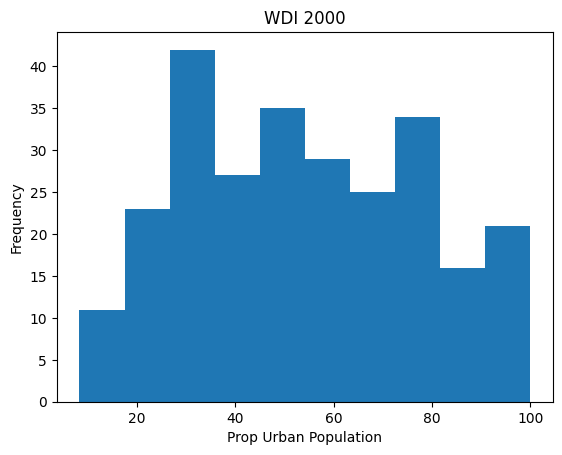

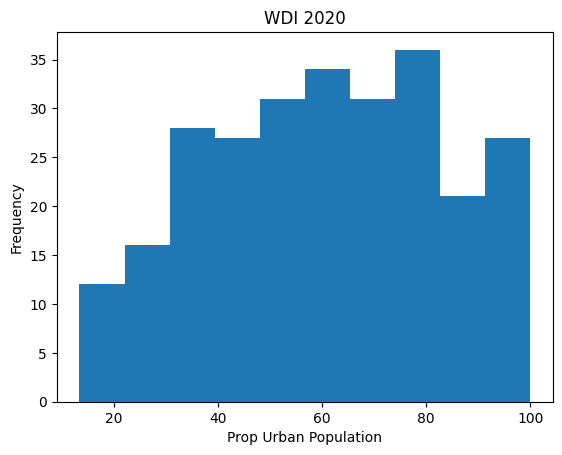

```python
# Note "prop_urbanpopulation" is the percentage of the urban population over
# the total population

# Hint: Before you write the loop, test your code out by opening an individual dataset
# Once you're sure the code works and you're familiar with the data, run the loop

# Write your answer here

wdi2000 = pd.read_csv('wdi_data/wdi_2000.csv')
wdi2020 = pd.read_csv('wdi_data/wdi_2020.csv')
list_wdis = [wdi2000, wdi2020]
wdi2000.name = "WDI 2000"
wdi2020.name = "WDI 2020"

for wdi in list_wdis:
    plt.hist(wdi["prop_urbanpopulation"])
    plt.title(wdi.name)
    plt.xlabel("Prop Urban Population")
    plt.ylabel("Frequency")
    plt.show()
```

For questions (d) and (e), use the following table:

[figure not shown]

(d) Loops with multiple lists

- Create three lists

list_lower = [93, 87, 83, 80, 75, 70, 65, 60, 55, 0]

list_upper = [100,92, 86, 82, 79, 74, 69, 64, 59, 54]

list_letters = ["A","A-","B+","B","B-","C+","C","C-","D","F"]

- Create a for loop that prints the message:

"If a students gets a grade between .... and ..., their letter grade is ..."

```python
# Hint: Use a for-loop with numbering
# Start the index at zero
# In the body of the loop, extract the elements in each list by the index position

# Write your answer here

list_lower = [93, 87, 83, 80, 75, 70, 65, 60, 55, 0]
list_upper = [100,92, 86, 82, 79, 74, 69, 64, 59, 54]
list_letters = ["A","A-","B+","B","B-","C+","C","C-","D","F"]

for id in range(len(list_lower)):
    print("If a student gets a grade between " + str(list_lower[id]) + " and " + str(list_upper[id]) + ", their letter grade is " + list_letters[id])
```

```
If a student gets a grade between 93 and 100, their letter grade is A
If a student gets a grade between 87 and 92, their letter grade is A-
If a student gets a grade between 83 and 86, their letter grade is B+
If a student gets a grade between 80 and 82, their letter grade is B
If a student gets a grade between 75 and 79, their letter grade is B-
If a student gets a grade between 70 and 74, their letter grade is C+
If a student gets a grade between 65 and 69, their letter grade is C
If a student gets a grade between 60 and 64, their letter grade is C-
If a student gets a grade between 55 and 59, their letter grade is D
If a student gets a grade between 0 and 54, their letter grade is F
```

(e) Classification with double loops

- Suppose that 5 students get the following grades:

list_studentgrades = [80, 92, 60, 42, 97]

- Print the following message:

"The student got a numeric grade of .... and their letter grade was ..."

```python
#(a) Hint: Use a double for loop structure:
#---- for studentgrade in list_studentgrades:
#----     index = 0
#----     for letter in list_letters:
#----          Body
#----          index = index + 1

# (b) Inside the body, use an if/else statement to print the correct letter grade.
# You can make your code more concise by doing similar steps to question (d).

# Write your answer here:

list_studentgrades = [80, 92, 60, 42, 97]

for studentgrade in list_studentgrades:
    index = 0
    for lower in list_lower:
        if (studentgrade < lower ):
            index = index + 1
    print ("The student got a numeric grade of" + str(studentgrade) + "and their letter grade was " + list_letters [index])
```

```
The student got a numeric grade of80and their letter grade was B
The student got a numeric grade of92and their letter grade was A-
The student got a numeric grade of60and their letter grade was C-
The student got a numeric grade of42and their letter grade was F
The student got a numeric grade of97and their letter grade was A
```